# Predicting Client Subscription for Bank’s Term Deposit

Evangeline Tan

### Introduction

With direct marketing campaigns of a Portuguese banking institution that were based on phone calls, more than one contact to the same client were often required so as to check if clients would subscribe to the bank’s term deposit.

The classification goal predicts if the client will subscribe (Y/N) to a term deposit (var y).

Data: [Bank Marketing Data Set](https://archive.ics.uci.edu/ml/datasets/Bank+Marketing)

Attributes: [GitHub](https://github.com/evantyy/client-subscription-predict/blob/main/dataset/bank-client-attributes.txt)

### Import data and libraries

```r
setwd("D:/et4_e")

#Import the bank marketing data
bank = read.table("bank.csv",sep=";",header=TRUE)

library(ggplot2)
library(dplyr)
library(gridExtra)

#Convert from character to factor
bank[sapply(bank, is.character)] <- lapply(bank[sapply(bank, is.character)],
                                           as.factor)
dim(bank)
```

```
## [1] 4521   17
```

There are 4,521 total observations and 17 variables in the bank data.

In this following section, the data will be analyzed and interpreted using different models such as Decision Tree, Logistic Regression and Random Forest. A comparison of predictive performances for the models will also be explained.

```r
# Remove unknown values
bank1 = bank
bank1[bank1=="unknown"] <- NA
sum(is.na(bank1))
```

```
## [1] 5254
```

```r
bank1 <- na.omit(bank1)
```

Before starting with the analysis, unknown missing values in the data were removed as it would affect the output and its bias.

With the remaining 764 observations, there are certain patterns within the observed data.

Since variables such as duration are obvious that highly affect the subscription choice, the focus will be on finding patterns within the data’s less obvious variables.

Variables such as age, job, marital status, education level and the number of contacts with the client during the campaign are explored to see the effects on the term deposit subscription choice.

### Analysis of data with specific variables

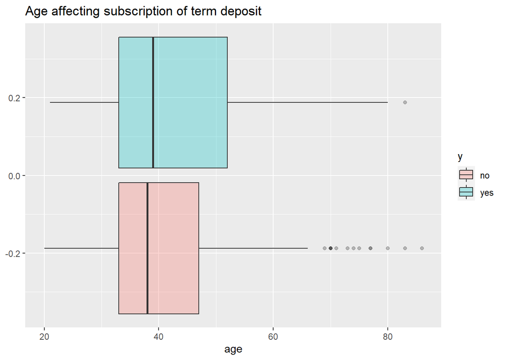

```r
# Checking if there are patterns between variables that affects Yes & No

ggplot(bank1, aes(x= age, fill = y)) + geom_boxplot(alpha = .3) + ggtitle("Age affecting subscription of term deposit")
```

Age is only slightly significant for affecting the predicted value.

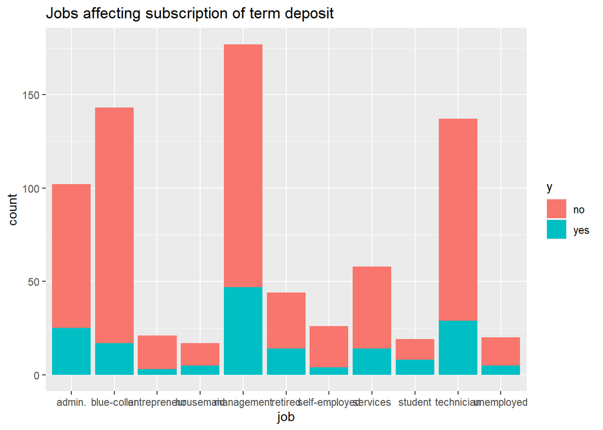

```r
ggplot(bank1, aes(x=job, fill=y)) + geom_bar() + ggtitle("Jobs affecting subscription of term deposit")
```

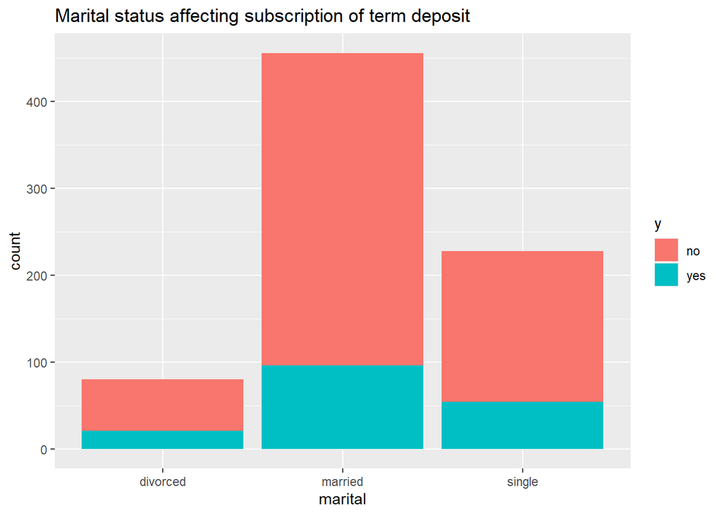

```r
ggplot(bank1, aes(x= marital, fill = y)) + geom_bar() + ggtitle("Marital status affecting subscription of term deposit")
```

Insignificant difference in pattern between marital and y, not a significant indicator.

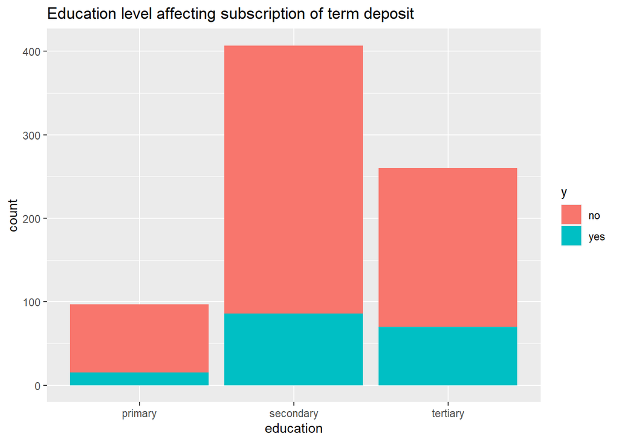

```r
ggplot(bank1, aes(x=education, fill = y)) + geom_bar() + ggtitle("Education level affecting subscription of term deposit")
```

Education have a similar even pattern, not a significant indicator.

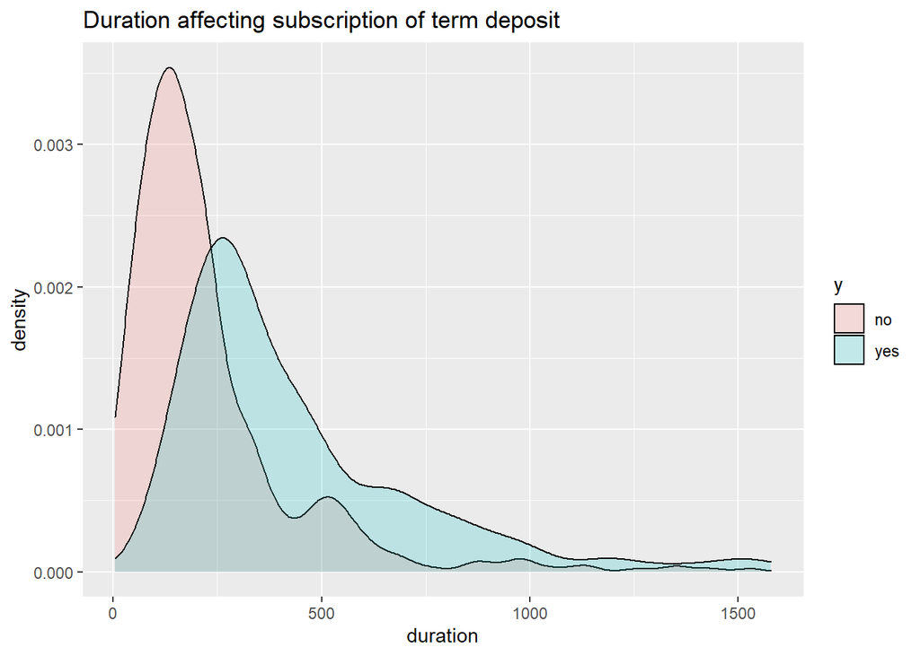

```r
ggplot(bank1, aes(x= duration, fill = y)) + geom_density(alpha = 0.2) + ggtitle("Duration affecting subscription of term deposit")
```

Benchmarking Purpose: longer the call, higher the chance of saying yes

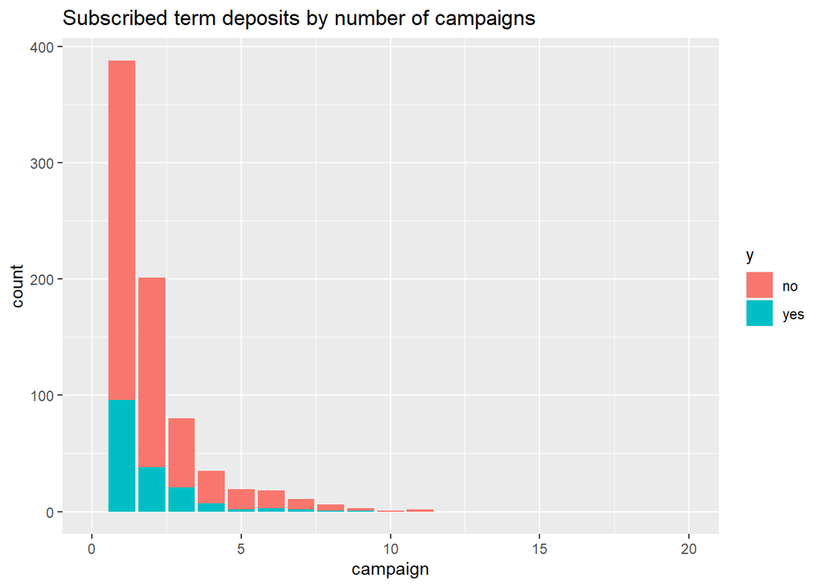

```r
ggplot(bank1, aes(x= campaign, fill = y)) + geom_bar() + xlim(0,20) + ggtitle("Subscribed term deposits by number of campaigns")
```

Significant result, since if a person says yes, then they will probably do it within first 4 campaigns.